# 서울시 상권 유형별 소비 패턴 군집화 분석

- 26-1 기계학습 HW2
- 정보융합학부 김민지 (2023510005)
- 서울 열린데이터광장의 상권분석서비스 데이터를 활용해 서울시 상권을 군집화하고, 실제 상권 구분(골목상권 / 발달상권 / 전통시장 / 관광특구)과 비교 분석한 프로젝트
- 데이터 출처: 서울 열린데이터광장

> > [상권분석서비스(추정매출-상권)](https://data.seoul.go.kr/dataList/OA-15572/S/1/datasetView.do)  
> > [상권분석서비스(점포-상권)](https://data.seoul.go.kr/dataList/OA-15577/S/1/datasetView.do)  
> > [상권분석서비스(직장인구-상권)](https://data.seoul.go.kr/dataList/OA-15569/S/1/datasetView.do)

## 0. 라이브러리 임포트

```python
import pandas as pd
import numpy as np
import matplotlib.pyplot as plt
import matplotlib.font_manager as fm
import matplotlib
import warnings
warnings.filterwarnings('ignore')

# 한글 폰트 설정
def set_korean_font():
    # 폰트 목록 (Mac / Linux / Windows 순서)
    candidates = [
        'AppleGothic',          # Mac
        'Apple SD Gothic Neo',  # Mac
        'NanumGothic',          # Linux/공통
        'NanumBarunGothic',
        'Malgun Gothic',        # Windows
        'DejaVu Sans',          # 폴백
    ]
    available = {f.name for f in fm.fontManager.ttflist}
    for font in candidates:
        if font in available:
            matplotlib.rcParams['font.family'] = font
            matplotlib.rcParams['axes.unicode_minus'] = False
            print(f'폰트 설정 완료: {font}')
            return font
    print('한글 폰트를 찾지 못했습니다. 아래 나눔폰트 설치를 권장합니다.')
    return None

set_korean_font()

import seaborn as sns

from sklearn.preprocessing import StandardScaler, LabelEncoder
from sklearn.cluster import KMeans, AgglomerativeClustering, DBSCAN, AffinityPropagation
from sklearn.metrics import silhouette_score, silhouette_samples
from sklearn.decomposition import PCA
from sklearn.manifold import TSNE

from scipy.cluster.hierarchy import dendrogram, linkage
from scipy.spatial.distance import cdist

print('라이브러리 로드 완료')
```

```
폰트 설정 완료: AppleGothic
라이브러리 로드 완료
```

## 1. 데이터 수집 및 이해

### 1-1. 데이터 로드

```python
# 파일 경로
base_path = '/Users/gomdori/Library/Mobile Documents/com~apple~CloudDocs/26-1 기계학습/ML_HW2_seoul-commercial-district-clustering'
SALES_PATH = f'{base_path}/Data/서울시_상권분석서비스(추정매출-상권)_2024년.csv'
STORE_PATH = f'{base_path}/Data/서울시_상권분석서비스(점포-상권)_2024년.csv'
WORK_PATH  = f'{base_path}/Data/서울시_상권분석서비스(직장인구-상권)_2024년.csv'
```

**추정매출-상권**

```python
df_sales = pd.read_csv(SALES_PATH, encoding='utf-8')
print(f'추정매출 shape: {df_sales.shape}')
df_sales.head(5)
```

```
추정매출 shape: (87179, 55)
```

|  | 기준_년분기_코드 | 상권_구분_코드 | 상권_구분_코드_명 | 상권_코드 | 상권_코드_명 | 서비스_업종_코드 | 서비스_업종_코드_명 | 당월_매출_금액 | 당월_매출_건수 | 주중_매출_금액 | ... | 시간대_건수~21_매출_건수 | 시간대_건수~24_매출_건수 | 남성_매출_건수 | 여성_매출_건수 | 연령대_10_매출_건수 | 연령대_20_매출_건수 | 연령대_30_매출_건수 | 연령대_40_매출_건수 | 연령대_50_매출_건수 | 연령대_60_이상_매출_건수 |
| --- | --- | --- | --- | --- | --- | --- | --- | --- | --- | --- | --- | --- | --- | --- | --- | --- | --- | --- | --- | --- | --- |
| 0 | 20241 | A | 골목상권 | 3110001 | 이북5도청사 | CS100001 | 한식음식점 | 385150643.0 | 11743 | 220129223.0 | ... | 3496 | 52 | 6023 | 4281 | 26 | 508 | 935 | 1997 | 3135 | 3704 |
| 1 | 20241 | A | 골목상권 | 3110001 | 이북5도청사 | CS100009 | 호프-간이주점 | 11026440.0 | 214 | 6576206.0 | ... | 123 | 39 | 103 | 78 | 0 | 0 | 0 | 32 | 55 | 95 |
| 2 | 20241 | A | 골목상권 | 3110001 | 이북5도청사 | CS200001 | 일반교습학원 | 52047765.0 | 224 | 50535211.0 | ... | 112 | 8 | 48 | 176 | 0 | 0 | 8 | 152 | 64 | 0 |
| 3 | 20241 | A | 골목상권 | 3110002 | 독립문역 1번 | CS100001 | 한식음식점 | 582522265.0 | 20630 | 404509479.0 | ... | 5358 | 487 | 11887 | 7589 | 17 | 914 | 2595 | 3483 | 5408 | 7049 |
| 4 | 20241 | A | 골목상권 | 3110002 | 독립문역 1번 | CS100005 | 제과점 | 446525280.0 | 40242 | 350264783.0 | ... | 11472 | 2634 | 16005 | 22755 | 329 | 3589 | 7446 | 8867 | 9543 | 8986 |

5 rows × 55 columns

**점포-상권**

```python
df_store = pd.read_csv(STORE_PATH, encoding='utf-8')
print(f'점포 shape: {df_store.shape}')
df_store.head(5)
```

```
점포 shape: (306889, 14)
```

|  | 기준_년분기_코드 | 상권_구분_코드 | 상권_구분_코드_명 | 상권_코드 | 상권_코드_명 | 서비스_업종_코드 | 서비스_업종_코드_명 | 점포_수 | 유사_업종_점포_수 | 개업_율 | 개업_점포_수 | 폐업_률 | 폐업_점포_수 | 프랜차이즈_점포_수 |
| --- | --- | --- | --- | --- | --- | --- | --- | --- | --- | --- | --- | --- | --- | --- |
| 0 | 20241 | A | 골목상권 | 3110001 | 이북5도청사 | CS100001 | 한식음식점 | 10 | 11 | 0 | 0 | 0 | 0 | 1 |
| 1 | 20241 | A | 골목상권 | 3110001 | 이북5도청사 | CS100003 | 일식음식점 | 1 | 1 | 0 | 0 | 0 | 0 | 0 |
| 2 | 20241 | A | 골목상권 | 3110001 | 이북5도청사 | CS100008 | 분식전문점 | 2 | 2 | 0 | 0 | 50 | 1 | 0 |
| 3 | 20241 | A | 골목상권 | 3110001 | 이북5도청사 | CS100009 | 호프-간이주점 | 4 | 5 | 20 | 1 | 0 | 0 | 1 |
| 4 | 20241 | A | 골목상권 | 3110001 | 이북5도청사 | CS100010 | 커피-음료 | 1 | 1 | 0 | 0 | 0 | 0 | 0 |

**직장인구-상권**

```python
df_work  = pd.read_csv(WORK_PATH,  encoding='utf-8')
print(f'직장인구 shape: {df_work.shape}')
df_work.head(5)
```

```
직장인구 shape: (45840, 26)
```

|  | 기준_년분기_코드 | 상권_구분_코드 | 상권_구분_코드_명 | 상권_코드 | 상권_코드_명 | 총_직장_인구_수 | 남성_직장_인구_수 | 여성_직장_인구_수 | 연령대_10_직장_인구_수 | 연령대_20_직장_인구_수 | ... | 남성연령대_30_직장_인구_수 | 남성연령대_40_직장_인구_수 | 남성연령대_50_직장_인구_수 | 남성연령대_60_이상_직장_인구_수 | 여성연령대_10_직장_인구_수 | 여성연령대_20_직장_인구_수 | 여성연령대_30_직장_인구_수 | 여성연령대_40_직장_인구_수 | 여성연령대_50_직장_인구_수 | 여성연령대_60_이상_직장_인구_수 |
| --- | --- | --- | --- | --- | --- | --- | --- | --- | --- | --- | --- | --- | --- | --- | --- | --- | --- | --- | --- | --- | --- |
| 0 | 20254 | U | 관광특구 | 3001496 | 강남 마이스 관광특구 | 102032 | 68834 | 33198 | 260 | 20558 | ... | 20220 | 20142 | 14200 | 3098 | 132 | 9512 | 10374 | 7178 | 3916 | 2086 |
| 1 | 20254 | U | 관광특구 | 3001495 | 잠실 관광특구 | 137602 | 81307 | 56295 | 247 | 22732 | ... | 22723 | 22594 | 16132 | 8520 | 152 | 11489 | 13330 | 12867 | 14189 | 4268 |
| 2 | 20254 | U | 관광특구 | 3001494 | 종로?청계 관광특구 | 46516 | 26098 | 20418 | 658 | 9450 | ... | 7232 | 7590 | 5236 | 1734 | 424 | 5378 | 6616 | 5060 | 2202 | 738 |
| 3 | 20254 | U | 관광특구 | 3001493 | 동대문패션타운 관광특구 | 33754 | 16984 | 16770 | 259 | 9770 | ... | 5003 | 3924 | 2083 | 1196 | 158 | 5093 | 3676 | 2954 | 3331 | 1558 |
| 4 | 20254 | U | 관광특구 | 3001492 | 명동 남대문 북창동 다동 무교동 관광특구 | 199667 | 114485 | 85182 | 372 | 40531 | ... | 35220 | 34082 | 23643 | 5957 | 289 | 25031 | 31540 | 17398 | 8109 | 2815 |

5 rows × 26 columns

### 1-2. 데이터 이해

**[추정매출-상권]** 55개 컬럼, 87,179행 (상권 × 업종 단위)

- 당월 매출금액/건수, 주중·주말, 요일별(7), 시간대별(6), 성별(2), 연령대별(6) 매출

**[점포-상권]** 14개 컬럼, 306,889행 (상권 × 업종 단위)

- 점포수, 유사업종점포수, 개업률·개업점포수, 폐업률·폐업점포수, 프랜차이즈점포수

**[직장인구-상권]** 26개 컬럼, 45,840행 (상권 × 분기 단위)

- 총직장인구, 남/여, 연령대별(6), 성별×연령대별(12) 직장인구

```python
# 분기별 분포 확인
TARGET_Q = 20244  # 2024년 4분기

print('[상권 구분 분포]')
print(df_sales[df_sales['기준_년분기_코드'] == TARGET_Q]
      .groupby('상권_구분_코드_명')['상권_코드'].nunique())

df_sales.head(3)
```

```
[상권 구분 분포]
상권_구분_코드_명
골목상권    1035
관광특구       6
발달상권     249
전통시장     280
Name: 상권_코드, dtype: int64
```

|  | 기준_년분기_코드 | 상권_구분_코드 | 상권_구분_코드_명 | 상권_코드 | 상권_코드_명 | 서비스_업종_코드 | 서비스_업종_코드_명 | 당월_매출_금액 | 당월_매출_건수 | 주중_매출_금액 | ... | 시간대_건수~21_매출_건수 | 시간대_건수~24_매출_건수 | 남성_매출_건수 | 여성_매출_건수 | 연령대_10_매출_건수 | 연령대_20_매출_건수 | 연령대_30_매출_건수 | 연령대_40_매출_건수 | 연령대_50_매출_건수 | 연령대_60_이상_매출_건수 |
| --- | --- | --- | --- | --- | --- | --- | --- | --- | --- | --- | --- | --- | --- | --- | --- | --- | --- | --- | --- | --- | --- |
| 0 | 20241 | A | 골목상권 | 3110001 | 이북5도청사 | CS100001 | 한식음식점 | 385150643.0 | 11743 | 220129223.0 | ... | 3496 | 52 | 6023 | 4281 | 26 | 508 | 935 | 1997 | 3135 | 3704 |
| 1 | 20241 | A | 골목상권 | 3110001 | 이북5도청사 | CS100009 | 호프-간이주점 | 11026440.0 | 214 | 6576206.0 | ... | 123 | 39 | 103 | 78 | 0 | 0 | 0 | 32 | 55 | 95 |
| 2 | 20241 | A | 골목상권 | 3110001 | 이북5도청사 | CS200001 | 일반교습학원 | 52047765.0 | 224 | 50535211.0 | ... | 112 | 8 | 48 | 176 | 0 | 0 | 8 | 152 | 64 | 0 |

3 rows × 55 columns

## 2. 전처리

### 2-1. 분기 필터 및 상권 단위 집계

```python
# ── 추정매출: 2024Q4 필터 후 상권별 sum ──────────────────────────
sales_num_cols = [
    '당월_매출_금액', '당월_매출_건수',
    '주중_매출_금액', '주말_매출_금액',
    '월요일_매출_금액', '화요일_매출_금액', '수요일_매출_금액',
    '목요일_매출_금액', '금요일_매출_금액', '토요일_매출_금액', '일요일_매출_금액',
    '시간대_00~06_매출_금액', '시간대_06~11_매출_금액', '시간대_11~14_매출_금액',
    '시간대_14~17_매출_금액', '시간대_17~21_매출_금액', '시간대_21~24_매출_금액',
    '남성_매출_금액', '여성_매출_금액',
    '연령대_10_매출_금액', '연령대_20_매출_금액', '연령대_30_매출_금액',
    '연령대_40_매출_금액', '연령대_50_매출_금액', '연령대_60_이상_매출_금액'
]

sales_q = df_sales[df_sales['기준_년분기_코드'] == TARGET_Q].copy()
sales_agg = (
    sales_q.groupby(['상권_코드', '상권_코드_명', '상권_구분_코드_명'])[sales_num_cols]
    .sum()
    .reset_index()
)

# ── 점포: 2024Q4 필터 후 상권별 sum ───────────────────────────────
store_num_cols = ['점포_수', '유사_업종_점포_수', '개업_점포_수', '폐업_점포_수', '프랜차이즈_점포_수']

store_q = df_store[df_store['기준_년분기_코드'] == TARGET_Q].copy()
store_agg = (
    store_q.groupby('상권_코드')[store_num_cols]
    .sum()
    .reset_index()
)

# ── 직장인구: 2024Q4 필터 ─────────────────────────────────────────
work_num_cols = [
    '총_직장_인구_수', '남성_직장_인구_수', '여성_직장_인구_수',
    '연령대_10_직장_인구_수', '연령대_20_직장_인구_수', '연령대_30_직장_인구_수',
    '연령대_40_직장_인구_수', '연령대_50_직장_인구_수', '연령대_60_이상_직장_인구_수'
]

work_q = df_work[df_work['기준_년분기_코드'] == TARGET_Q][['상권_코드'] + work_num_cols].copy()

print(f'매출 집계: {sales_agg.shape}, 점포 집계: {store_agg.shape}, 직장인구: {work_q.shape}')
```

```
매출 집계: (1570, 28), 점포 집계: (1650, 6), 직장인구: (1641, 10)
```

### 2-2. 비율 변수 생성 (상권 규모 정규화)

```python
# 절대금액 대신 '비율 변수'를 사용 → 상권 크기 편차 제거
eps = 1  # 0 나누기 방지

# 주중/주말 비율
sales_agg['주중_매출_비율'] = sales_agg['주중_매출_금액'] / (sales_agg['당월_매출_금액'] + eps)
sales_agg['주말_매출_비율'] = sales_agg['주말_매출_금액'] / (sales_agg['당월_매출_금액'] + eps)

# 요일별 비율
for day in ['월요일', '화요일', '수요일', '목요일', '금요일', '토요일', '일요일']:
    sales_agg[f'{day}_매출_비율'] = sales_agg[f'{day}_매출_금액'] / (sales_agg['당월_매출_금액'] + eps)

# 시간대별 비율
for t in ['00~06', '06~11', '11~14', '14~17', '17~21', '21~24']:
    sales_agg[f'시간대_{t}_비율'] = sales_agg[f'시간대_{t}_매출_금액'] / (sales_agg['당월_매출_금액'] + eps)

# 성별 비율
sales_agg['여성_매출_비율'] = sales_agg['여성_매출_금액'] / (sales_agg['당월_매출_금액'] + eps)

# 연령대별 비율
for age in ['10', '20', '30', '40', '50', '60_이상']:
    sales_agg[f'연령대_{age}_비율'] = sales_agg[f'연령대_{age}_매출_금액'] / (sales_agg['당월_매출_금액'] + eps)

# 프랜차이즈 비율 (점포 대비)
store_agg['프랜차이즈_비율'] = store_agg['프랜차이즈_점포_수'] / (store_agg['점포_수'] + eps)
store_agg['개업_비율']       = store_agg['개업_점포_수'] / (store_agg['점포_수'] + eps)
store_agg['폐업_비율']       = store_agg['폐업_점포_수'] / (store_agg['점포_수'] + eps)

# 직장인구 성별 비율
work_q = work_q.copy()
work_q['직장_여성_비율'] = work_q['여성_직장_인구_수'] / (work_q['총_직장_인구_수'] + eps)
work_q['직장_2030_비율'] = (work_q['연령대_20_직장_인구_수'] + work_q['연령대_30_직장_인구_수']) / (work_q['총_직장_인구_수'] + eps)

print('비율 변수 생성 완료')
```

```
비율 변수 생성 완료
```

### 2-3. 세 데이터 병합

```python
# merge
df = sales_agg.merge(store_agg, on='상권_코드', how='left')
df = df.merge(work_q, on='상권_코드', how='left')

print(f'병합 후 shape: {df.shape}')
print(f'결측값:\n{df.isnull().sum()[df.isnull().sum() > 0]}')
```

```
병합 후 shape: (1570, 69)
결측값:
총_직장_인구_수            6
남성_직장_인구_수           6
여성_직장_인구_수           6
연령대_10_직장_인구_수       6
연령대_20_직장_인구_수       6
연령대_30_직장_인구_수       6
연령대_40_직장_인구_수       6
연령대_50_직장_인구_수       6
연령대_60_이상_직장_인구_수    6
직장_여성_비율             6
직장_2030_비율           6
dtype: int64
```

### 2-4. 분석용 feature 선택 및 결측치·이상치 처리

```python
# 분석에 사용할 feature 목록 (총 28개)
FEATURE_COLS = [
    # 매출 규모 (log 변환 예정)
    '당월_매출_금액',
    # 주중/주말
    '주중_매출_비율', '주말_매출_비율',
    # 요일별 비율
    '월요일_매출_비율', '화요일_매출_비율', '수요일_매출_비율',
    '목요일_매출_비율', '금요일_매출_비율', '토요일_매출_비율', '일요일_매출_비율',
    # 시간대별 비율
    '시간대_00~06_비율', '시간대_06~11_비율', '시간대_11~14_비율',
    '시간대_14~17_비율', '시간대_17~21_비율', '시간대_21~24_비율',
    # 성별
    '여성_매출_비율',
    # 연령대
    '연령대_10_비율', '연령대_20_비율', '연령대_30_비율',
    '연령대_40_비율', '연령대_50_비율', '연령대_60_이상_비율',
    # 점포
    '점포_수', '프랜차이즈_비율', '개업_비율', '폐업_비율',
    # 직장인구
    '총_직장_인구_수', '직장_여성_비율', '직장_2030_비율'
]

df_feat = df[['상권_코드', '상권_코드_명', '상권_구분_코드_명'] + FEATURE_COLS].copy()

# 결측치 처리: 직장인구 없는 상권은 0으로 채움
df_feat[FEATURE_COLS] = df_feat[FEATURE_COLS].fillna(0)

# 매출 0인 상권 제거 (데이터 없는 상권)
df_feat = df_feat[df_feat['당월_매출_금액'] > 0].reset_index(drop=True)

# 매출 금액 log 변환 (우편포를 정규분포에 가깝게)
df_feat['당월_매출_금액'] = np.log1p(df_feat['당월_매출_금액'])
df_feat['점포_수']        = np.log1p(df_feat['점포_수'])
df_feat['총_직장_인구_수'] = np.log1p(df_feat['총_직장_인구_수'])

print(f'최종 분석 데이터: {df_feat.shape}')
print(f'feature 수: {len(FEATURE_COLS)}개')
df_feat[FEATURE_COLS].describe().round(3)
```

```
최종 분석 데이터: (1570, 33)
feature 수: 30개
```

|  | 당월_매출_금액 | 주중_매출_비율 | 주말_매출_비율 | 월요일_매출_비율 | 화요일_매출_비율 | 수요일_매출_비율 | 목요일_매출_비율 | 금요일_매출_비율 | 토요일_매출_비율 | 일요일_매출_비율 | ... | 연령대_40_비율 | 연령대_50_비율 | 연령대_60_이상_비율 | 점포_수 | 프랜차이즈_비율 | 개업_비율 | 폐업_비율 | 총_직장_인구_수 | 직장_여성_비율 | 직장_2030_비율 |
| --- | --- | --- | --- | --- | --- | --- | --- | --- | --- | --- | --- | --- | --- | --- | --- | --- | --- | --- | --- | --- | --- |
| count | 1570.000 | 1570.000 | 1570.000 | 1570.000 | 1570.000 | 1570.000 | 1570.000 | 1570.000 | 1570.000 | 1570.000 | ... | 1570.000 | 1570.000 | 1570.000 | 1570.000 | 1570.000 | 1570.000 | 1570.000 | 1570.000 | 1570.000 | 1570.000 |
| mean | 21.866 | 0.759 | 0.241 | 0.147 | 0.161 | 0.141 | 0.147 | 0.163 | 0.148 | 0.093 | ... | 0.204 | 0.215 | 0.226 | 5.062 | 0.087 | 0.023 | 0.028 | 6.322 | 0.397 | 0.359 |
| std | 1.905 | 0.092 | 0.092 | 0.052 | 0.046 | 0.040 | 0.046 | 0.042 | 0.055 | 0.055 | ... | 0.105 | 0.076 | 0.134 | 1.053 | 0.055 | 0.016 | 0.020 | 1.690 | 0.101 | 0.126 |
| min | 13.077 | 0.000 | 0.000 | 0.000 | 0.000 | 0.000 | 0.000 | 0.000 | 0.000 | 0.000 | ... | 0.000 | 0.000 | 0.000 | 2.485 | 0.000 | 0.000 | 0.000 | 0.000 | 0.000 | 0.000 |
| 25% | 20.813 | 0.710 | 0.195 | 0.124 | 0.142 | 0.126 | 0.130 | 0.147 | 0.123 | 0.060 | ... | 0.148 | 0.171 | 0.131 | 4.331 | 0.052 | 0.012 | 0.016 | 5.347 | 0.345 | 0.290 |
| 50% | 21.950 | 0.756 | 0.244 | 0.146 | 0.157 | 0.137 | 0.141 | 0.161 | 0.152 | 0.090 | ... | 0.183 | 0.218 | 0.210 | 5.030 | 0.080 | 0.022 | 0.027 | 6.192 | 0.404 | 0.367 |
| 75% | 23.105 | 0.805 | 0.290 | 0.166 | 0.174 | 0.150 | 0.156 | 0.176 | 0.173 | 0.123 | ... | 0.232 | 0.252 | 0.299 | 5.645 | 0.114 | 0.031 | 0.038 | 7.244 | 0.457 | 0.450 |
| max | 27.841 | 1.000 | 1.000 | 0.877 | 0.813 | 0.526 | 1.000 | 1.000 | 1.000 | 0.962 | ... | 1.000 | 0.976 | 1.000 | 9.518 | 0.441 | 0.125 | 0.211 | 12.204 | 0.811 | 0.678 |

8 rows × 30 columns

### 2-5. 스케일링 및 Label 분리

```python
# Label 저장 (군집화 입력에는 사용 안 함 - external evaluation 용)
y_true_str = df_feat['상권_구분_코드_명'].values
le = LabelEncoder()
y_true = le.fit_transform(y_true_str)
print('클래스 매핑:', dict(zip(le.classes_, le.transform(le.classes_))))

# StandardScaler 적용
scaler = StandardScaler()
X = scaler.fit_transform(df_feat[FEATURE_COLS])

print(f'\nX shape: {X.shape}')
print(f'평균(첫 3개 feature): {X.mean(axis=0)[:3].round(3)}')
print(f'표준편차(첫 3개 feature): {X.std(axis=0)[:3].round(3)}')
```

```
클래스 매핑: {'골목상권': 0, '관광특구': 1, '발달상권': 2, '전통시장': 3}

X shape: (1570, 30)
평균(첫 3개 feature): [-0.  0. -0.]
표준편차(첫 3개 feature): [1. 1. 1.]
```

## 3. 군집화 분석

### 3-1. K-Means

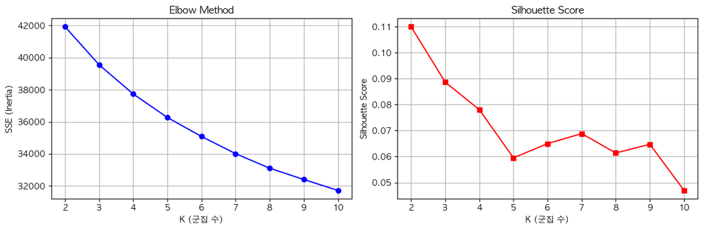

```
K별 Silhouette Score:
  K=2: 0.1100
  K=3: 0.0887
  K=4: 0.0781
  K=5: 0.0595
  K=6: 0.0650
  K=7: 0.0688
  K=8: 0.0614
  K=9: 0.0648
  K=10: 0.0470
```

```python
# ── Elbow Method (SSE) ────────────────────────────────────────────
sse = []
sil = []
K_range = range(2, 11)

for k in K_range:
    km = KMeans(n_clusters=k, random_state=42, n_init=10)
    labels = km.fit_predict(X)
    sse.append(km.inertia_)
    sil.append(silhouette_score(X, labels))

fig, axes = plt.subplots(1, 2, figsize=(12, 4))

axes[0].plot(K_range, sse, 'bo-')
axes[0].set_xlabel('K (군집 수)')
axes[0].set_ylabel('SSE (Inertia)')
axes[0].set_title('Elbow Method')
axes[0].grid(True)

axes[1].plot(K_range, sil, 'rs-')
axes[1].set_xlabel('K (군집 수)')
axes[1].set_ylabel('Silhouette Score')
axes[1].set_title('Silhouette Score')
axes[1].grid(True)

plt.tight_layout()
plt.savefig('plot_kmeans_tuning.png', dpi=150, bbox_inches='tight')
plt.show()

print('K별 Silhouette Score:')
for k, s in zip(K_range, sil):
    print(f'  K={k}: {s:.4f}')
```

```python
# ── 최적 K로 최종 K-Means ─────────────────────────────────────────
BEST_K = 4  # Elbow/Silhouette 결과 보고 조정 (label 클래스 수와 맞춤)

km_best = KMeans(n_clusters=BEST_K, random_state=42, n_init=10)
km_labels = km_best.fit_predict(X)

df_feat['kmeans_label'] = km_labels

print(f'K-Means (K={BEST_K}) 결과')
print(f'  SSE: {km_best.inertia_:.2f}')
print(f'  Silhouette Score: {silhouette_score(X, km_labels):.4f}')
print(f'  군집별 크기:\n{pd.Series(km_labels).value_counts().sort_index()}')
```

```
K-Means (K=4) 결과
  SSE: 37735.39
  Silhouette Score: 0.0781
  군집별 크기:
0    260
1    350
2    633
3    327
Name: count, dtype: int64
```

### 3-2. Hierarchical Clustering (계층적 군집화)

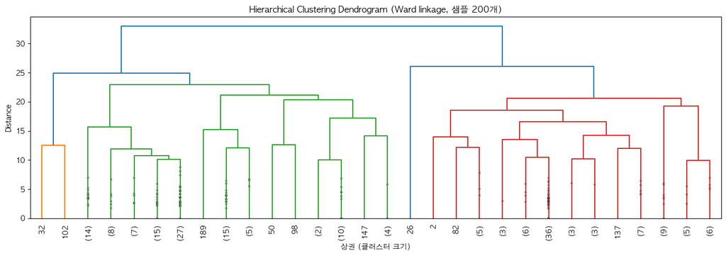

```python
# ── Dendrogram (샘플 200개로 시각화) ─────────────────────────────
from sklearn.utils import resample
idx_sample = resample(range(len(X)), n_samples=200, random_state=42)
X_sample = X[idx_sample]

linked = linkage(X_sample, method='ward')

plt.figure(figsize=(14, 5))
dendrogram(linked, truncate_mode='lastp', p=30,
           leaf_rotation=90, leaf_font_size=10, show_contracted=True)
plt.title('Hierarchical Clustering Dendrogram (Ward linkage, 샘플 200개)')
plt.xlabel('상권 (클러스터 크기)')
plt.ylabel('Distance')
plt.tight_layout()
plt.savefig('plot_dendrogram.png', dpi=150, bbox_inches='tight')
plt.show()
```

```python
# ── linkage 방법별 Silhouette 비교 ────────────────────────────────
linkage_methods = ['ward', 'complete', 'average']
hier_results = {}

for method in linkage_methods:
    hc = AgglomerativeClustering(n_clusters=BEST_K, linkage=method)
    labels = hc.fit_predict(X)
    sil = silhouette_score(X, labels)
    hier_results[method] = (labels, sil)
    print(f'  Hierarchical ({method:8s}): Silhouette={sil:.4f}')

# 최적 linkage 선택
best_method = max(hier_results, key=lambda m: hier_results[m][1])
hier_labels = hier_results[best_method][0]
df_feat['hier_label'] = hier_labels
print(f'\n채택 linkage: {best_method} (Silhouette={hier_results[best_method][1]:.4f})')
```

```
  Hierarchical (ward    ): Silhouette=0.0575
  Hierarchical (complete): Silhouette=0.7133
  Hierarchical (average ): Silhouette=0.7134

채택 linkage: average (Silhouette=0.7134)
```

```
=== Linkage별 상세 비교 ===

[ward] Silhouette=0.0575
col_0  골목상권  관광특구  발달상권  전통시장
row_0
0       384     2   169   161
1       350     0    10    65
2       133     4    50    24
3       168     0    20    30

[complete] Silhouette=0.7133
col_0  골목상권  관광특구  발달상권  전통시장
row_0
0         1     0     0     1
1      1032     6   249   279
2         1     0     0     0
3         1     0     0     0

[average] Silhouette=0.7134
col_0  골목상권  관광특구  발달상권  전통시장
row_0
0      1033     6   249   279
1         0     0     0     1
2         1     0     0     0
3         1     0     0     0

(시스템) 시각화를 위한 PCA 2D 변환을 완료했습니다.
```

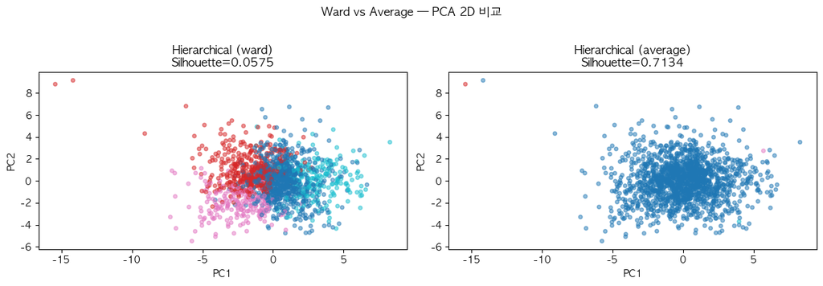

```
※ Average linkage의 Silhouette이 높게 나오는 이유:
  Silhouette은 평균 거리 기반으로 계산되므로,
  같은 평균 거리를 최적화하는 Average linkage에서
  artificially inflate(수치가 부풀려짐)될 수 있음.
  → 시각화로 군집 구조가 실제로 의미 있는지 직접 확인 필요.
```

```python
# Ward vs Average 비교 + Average inflation 검증
print('=== Linkage별 상세 비교 ===')
for method, (labels, sil) in hier_results.items():
    print(f'\n[{method}] Silhouette={sil:.4f}')
    cross = pd.crosstab(labels, y_true_str)
    print(cross)

# NameError 해결을 위해 PCA 2D 변환 코드 추가
if 'X_pca2' not in locals():
    pca2 = PCA(n_components=2, random_state=42)
    X_pca2 = pca2.fit_transform(X)
    print("\n(시스템) 시각화를 위한 PCA 2D 변환을 완료했습니다.")

# Average linkage inflation 여부 시각적 확인
fig, axes = plt.subplots(1, 2, figsize=(12, 4))
for ax, method in zip(axes, ['ward', 'average']):
    labels, sil = hier_results[method]
    ax.scatter(X_pca2[:, 0], X_pca2[:, 1],
               c=labels, cmap='tab10', alpha=0.5, s=15)
    ax.set_title(f'Hierarchical ({method})\nSilhouette={sil:.4f}')
    ax.set_xlabel('PC1'); ax.set_ylabel('PC2')

plt.suptitle('Ward vs Average — PCA 2D 비교', y=1.02)
plt.tight_layout()
plt.savefig('plot_hier_ward_vs_average.png', dpi=150, bbox_inches='tight')
plt.show()

print('\n※ Average linkage의 Silhouette이 높게 나오는 이유:')
print('  Silhouette은 평균 거리 기반으로 계산되므로,')
print('  같은 평균 거리를 최적화하는 Average linkage에서')
print('  artificially inflate(수치가 부풀려짐)될 수 있음.')
print('  → 시각화로 군집 구조가 실제로 의미 있는지 직접 확인 필요.')
```

### 3-3. DBSCAN

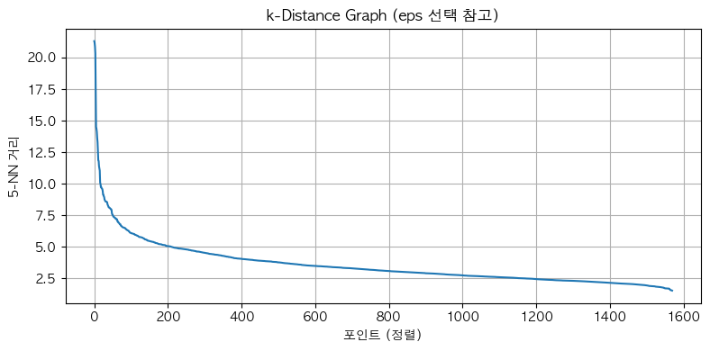

```python
# ── k-dist graph로 eps 탐색 ───────────────────────────────────────
from sklearn.neighbors import NearestNeighbors

k_nn = 5
nbrs = NearestNeighbors(n_neighbors=k_nn).fit(X)
distances, _ = nbrs.kneighbors(X)
k_distances = np.sort(distances[:, k_nn-1])[::-1]

plt.figure(figsize=(8, 4))
plt.plot(k_distances)
plt.xlabel('포인트 (정렬)')
plt.ylabel(f'{k_nn}-NN 거리')
plt.title('k-Distance Graph (eps 선택 참고)')
plt.grid(True)
plt.tight_layout()
plt.savefig('plot_kdistance.png', dpi=150, bbox_inches='tight')
plt.show()
```

```python
# ── eps / min_samples 그리드 탐색 ─────────────────────────────────
eps_list = [1.5, 2.0, 2.5, 3.0, 3.5]
min_samples_list = [3, 5, 10]

dbscan_results = []
for eps in eps_list:
    for ms in min_samples_list:
        db = DBSCAN(eps=eps, min_samples=ms)
        labels = db.fit_predict(X)
        n_clusters = len(set(labels)) - (1 if -1 in labels else 0)
        noise_ratio = (labels == -1).sum() / len(labels)
        sil = silhouette_score(X, labels) if n_clusters > 1 else -1
        dbscan_results.append({'eps': eps, 'min_samples': ms,
                               'n_clusters': n_clusters,
                               'noise_ratio': round(noise_ratio, 3),
                               'silhouette': round(sil, 4)})

dbscan_df = pd.DataFrame(dbscan_results)
print(dbscan_df.to_string(index=False))
```

```
 eps  min_samples  n_clusters  noise_ratio  silhouette
 1.5            3           4        0.989     -0.3242
 1.5            5           0        1.000     -1.0000
 1.5           10           0        1.000     -1.0000
 2.0            3           9        0.845     -0.2946
 2.0            5           2        0.880     -0.1790
 2.0           10           1        0.920     -1.0000
 2.5            3           6        0.618     -0.2019
 2.5            5           1        0.644     -1.0000
 2.5           10           1        0.669     -1.0000
 3.0            3           2        0.416      0.0688
 3.0            5           2        0.437      0.0231
 3.0           10           1        0.466     -1.0000
 3.5            3           2        0.278      0.1452
 3.5            5           1        0.289     -1.0000
 3.5           10           1        0.310     -1.0000
```

```python
# ── 최적 파라미터로 DBSCAN ───────────────────────────────────────
# 위 결과 보고 n_clusters가 2~6 사이이면서 noise_ratio 낮은 조합을 선택함.
BEST_EPS = 3.5
BEST_MS  = 4

db_best = DBSCAN(eps=BEST_EPS, min_samples=BEST_MS)
db_labels = db_best.fit_predict(X)
n_db_clusters = len(set(db_labels)) - (1 if -1 in db_labels else 0)

df_feat['dbscan_label'] = db_labels

print(f'DBSCAN (eps={BEST_EPS}, min_samples={BEST_MS})')
print(f'  군집 수: {n_db_clusters}')
print(f'  노이즈 비율: {(db_labels==-1).sum()/len(db_labels):.3f}')
if n_db_clusters > 1:
    print(f'  Silhouette Score: {silhouette_score(X, db_labels):.4f}')
print(f'  군집별 크기:\n{pd.Series(db_labels).value_counts().sort_index()}')
print('\n[해석] 서울 상권 데이터는 DBSCAN이 가정하는 명확한 밀도 경계가 없는\n연속적 밀도 구조를 가짐. 이는 골목상권이 지리적·상업적으로 서울 전역에\n균일하게 분포하며 고밀도 클러스터를 형성하지 않는다는 도메인 특성과 일치.')
```

```
DBSCAN (eps=3.5, min_samples=4)
  군집 수: 1
  노이즈 비율: 0.285
  군집별 크기:
-1     448
 0    1122
Name: count, dtype: int64

[해석] 서울 상권 데이터는 DBSCAN이 가정하는 명확한 밀도 경계가 없는
연속적 밀도 구조를 가짐. 이는 골목상권이 지리적·상업적으로 서울 전역에
균일하게 분포하며 고밀도 클러스터를 형성하지 않는다는 도메인 특성과 일치.
```

### 3-4. Affinity Propagation

```python
# damping 파라미터 탐색
# 데이터가 많으면 오래 걸릴 수 있으므로 500개 샘플로 탐색
from sklearn.utils import resample as sk_resample
X_ap = sk_resample(X, n_samples=min(500, len(X)), random_state=42)

damping_list = [0.5, 0.6, 0.7, 0.8, 0.9]
ap_results = []

for d in damping_list:
    # ConvergenceWarning을 무시하기 위해 max_iter를 충분히 줌
    ap = AffinityPropagation(damping=d, random_state=42, max_iter=500)
    labels = ap.fit_predict(X_ap)
    n_cl = len(set(labels))
    sil = silhouette_score(X_ap, labels) if n_cl > 1 else -1
    ap_results.append({'damping': d, 'n_clusters': n_cl, 'silhouette': round(sil, 4)})

ap_df = pd.DataFrame(ap_results)
print(ap_df.to_string(index=False))

# 실루엣 계수가 가장 높은 damping 값을 BEST_DAMPING에 저장
BEST_DAMPING = ap_df.loc[ap_df['silhouette'].idxmax(), 'damping']
print(f'\n→ 탐색 결과 최적의 damping: {BEST_DAMPING}')
```

```
 damping  n_clusters  silhouette
     0.5          72      0.1330
     0.6          72      0.1276
     0.7          76      0.1444
     0.8          74      0.1422
     0.9          54      0.0714

→ 탐색 결과 최적의 damping: 0.7
```

```python
# 전체 데이터 AP: preference 루프로 군집 수 탐색
# (AP는 군집 수를 직접 정하지 못하므로 preference를 통해 조절)
pref_list = [-200, -150, -100, -75, -50, -30]
ap_loop_results = []

print(f'사용 중인 Damping: {BEST_DAMPING}')
for pref in pref_list:
    ap = AffinityPropagation(
        damping=BEST_DAMPING,
        preference=pref,
        random_state=42,
        max_iter=500
    )
    labels = ap.fit_predict(X)
    n_cl = len(set(labels))
    sil = silhouette_score(X, labels) if n_cl > 1 else -1
    ap_loop_results.append({
        'preference': pref,
        'n_clusters': n_cl,
        'silhouette': round(sil, 4)
    })
    print(f'preference={pref:5d} | n_clusters={n_cl:4d} | silhouette={sil:.4f}')

ap_loop_df = pd.DataFrame(ap_loop_results)

# n_clusters가 2~20 사이인 결과 중 silhouette 최대인 것 자동 선택
valid = ap_loop_df[ap_loop_df['n_clusters'].between(2, 20)]
if not valid.empty:
    best_row = valid.loc[valid['silhouette'].idxmax()]
    BEST_PREF = int(best_row['preference'])
    print(f'\n→ 채택: preference={BEST_PREF}, '
          f'n_clusters={int(best_row["n_clusters"])}, '
          f'silhouette={best_row["silhouette"]:.4f}')
else:
    # 유효 범위 내 결과가 없으면 군집 수가 가장 적절한 것 선택
    best_row = ap_loop_df.loc[ap_loop_df['n_clusters'].idxmin()]
    BEST_PREF = int(best_row['preference'])
    print(f'\n→ (유효 범위 없음) 최소 군집 채택: preference={BEST_PREF}')

# 최종 AP 모델 학습 및 라벨 저장
ap_best = AffinityPropagation(
    damping=BEST_DAMPING,
    preference=BEST_PREF,
    random_state=42,
    max_iter=1000 # 최종 학습은 반복 횟수를 넉넉히 줌
)
ap_labels = ap_best.fit_predict(X)
df_feat['ap_label'] = ap_labels

n_ap = len(set(ap_labels))
sil_ap = silhouette_score(X, ap_labels) if n_ap > 1 else -1
print(f'\n최종 AP 분석 완료 — n_clusters={n_ap}, silhouette={sil_ap:.4f}')
```

```
사용 중인 Damping: 0.7
preference= -200 | n_clusters=  32 | silhouette=0.0272
preference= -150 | n_clusters=  43 | silhouette=0.0203
preference= -100 | n_clusters=  60 | silhouette=0.0257
preference=  -75 | n_clusters=  85 | silhouette=0.0234
preference=  -50 | n_clusters= 140 | silhouette=0.0263
preference=  -30 | n_clusters= 243 | silhouette=0.0336

→ (유효 범위 없음) 최소 군집 채택: preference=-200

최종 AP 분석 완료 — n_clusters=32, silhouette=0.0272
```

### 3-5. 알고리즘별 성능 비교

```python
results_summary = pd.DataFrame([
    {
        'Algorithm': 'K-Means',
        'Hyperparameter': f'K={BEST_K}',
        'n_clusters': BEST_K,
        'SSE': round(km_best.inertia_, 2),
        'Silhouette': round(silhouette_score(X, km_labels), 4)
    },
    {
        'Algorithm': 'Hierarchical',
        'Hyperparameter': f'linkage={best_method}',
        'n_clusters': BEST_K,
        'SSE': '-',
        'Silhouette': round(hier_results[best_method][1], 4)
    },
    {
        'Algorithm': 'DBSCAN',
        'Hyperparameter': f'eps={BEST_EPS}, min_samples={BEST_MS}',
        'n_clusters': n_db_clusters,
        'SSE': '-',
        'Silhouette': round(silhouette_score(X, db_labels), 4) if n_db_clusters > 1 else '-'
    },
    {
        'Algorithm': 'Affinity Propagation',
        'Hyperparameter': f'damping={BEST_DAMPING}',
        'n_clusters': n_ap,
        'SSE': '-',
        'Silhouette': round(sil_ap, 4)
    }
])

print('=== 알고리즘별 군집화 성능 비교 ===')
print(results_summary.to_string(index=False))
```

```
=== 알고리즘별 군집화 성능 비교 ===
           Algorithm         Hyperparameter  n_clusters       SSE Silhouette
             K-Means                    K=4           4  37735.39     0.0781
        Hierarchical        linkage=average           4         -     0.7134
              DBSCAN eps=3.5, min_samples=4           1         -          -
Affinity Propagation            damping=0.7          32         -     0.0272
```

## 4. 군집 결과 분석 및 시각화

### 4-1. PCA 2D 시각화

```
PCA 2D 설명 분산 비율: [0.18601701 0.11424689]
누적 설명 분산: 0.3003
```

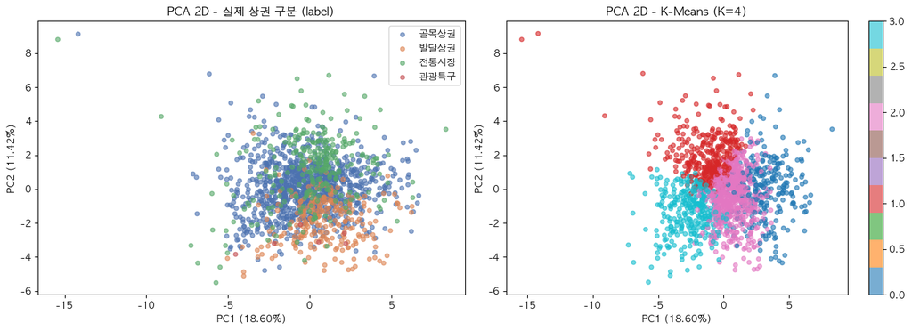

```python
# PCA 2D
pca2 = PCA(n_components=2, random_state=42)
X_pca2 = pca2.fit_transform(X)

print(f'PCA 2D 설명 분산 비율: {pca2.explained_variance_ratio_}')
print(f'누적 설명 분산: {pca2.explained_variance_ratio_.sum():.4f}')

# 상권 구분별 색상
label_colors = {'골목상권': '#4C72B0', '발달상권': '#DD8452', '전통시장': '#55A868', '관광특구': '#C44E52'}
color_map = [label_colors.get(l, 'gray') for l in y_true_str]

fig, axes = plt.subplots(1, 2, figsize=(14, 5))

# 실제 label
for label_name, color in label_colors.items():
    mask = y_true_str == label_name
    axes[0].scatter(X_pca2[mask, 0], X_pca2[mask, 1],
                    c=color, label=label_name, alpha=0.6, s=20)
axes[0].set_title('PCA 2D - 실제 상권 구분 (label)')
axes[0].legend()
axes[0].set_xlabel(f'PC1 ({pca2.explained_variance_ratio_[0]:.2%})')
axes[0].set_ylabel(f'PC2 ({pca2.explained_variance_ratio_[1]:.2%})')

# K-Means 군집 결과
scatter = axes[1].scatter(X_pca2[:, 0], X_pca2[:, 1],
                          c=km_labels, cmap='tab10', alpha=0.6, s=20)
axes[1].set_title(f'PCA 2D - K-Means (K={BEST_K})')
plt.colorbar(scatter, ax=axes[1])
axes[1].set_xlabel(f'PC1 ({pca2.explained_variance_ratio_[0]:.2%})')
axes[1].set_ylabel(f'PC2 ({pca2.explained_variance_ratio_[1]:.2%})')

plt.tight_layout()
plt.savefig('plot_pca2d.png', dpi=150, bbox_inches='tight')
plt.show()
```

### 4-2. PCA 3D 시각화

```
PCA 3D 누적 설명 분산: 0.3815
```

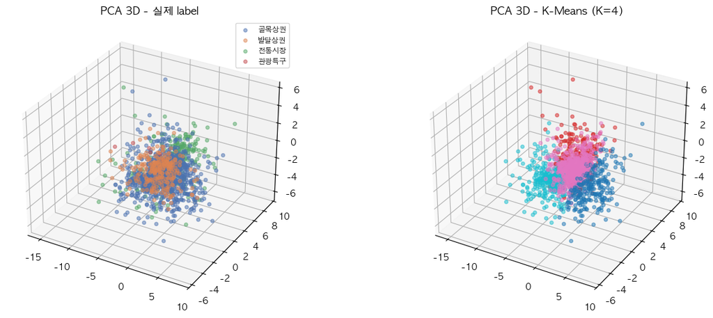

```python
from mpl_toolkits.mplot3d import Axes3D

pca3 = PCA(n_components=3, random_state=42)
X_pca3 = pca3.fit_transform(X)
print(f'PCA 3D 누적 설명 분산: {pca3.explained_variance_ratio_.sum():.4f}')

fig = plt.figure(figsize=(14, 5))

# 실제 label
ax1 = fig.add_subplot(121, projection='3d')
for label_name, color in label_colors.items():
    mask = y_true_str == label_name
    ax1.scatter(X_pca3[mask, 0], X_pca3[mask, 1], X_pca3[mask, 2],
                c=color, label=label_name, alpha=0.5, s=15)
ax1.set_title('PCA 3D - 실제 label')
ax1.legend(fontsize=8)

# K-Means
ax2 = fig.add_subplot(122, projection='3d')
sc = ax2.scatter(X_pca3[:, 0], X_pca3[:, 1], X_pca3[:, 2],
                 c=km_labels, cmap='tab10', alpha=0.5, s=15)
ax2.set_title(f'PCA 3D - K-Means (K={BEST_K})')

plt.tight_layout()
plt.savefig('plot_pca3d.png', dpi=150, bbox_inches='tight')
plt.show()
```

### 4-3. t-SNE 시각화

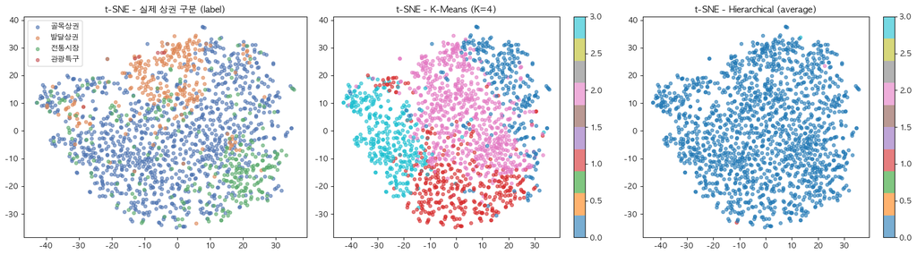

```python
# t-SNE
import sklearn
from packaging import version

# sklearn 버전에 따라 파라미터명 분기
tsne_kwargs = dict(n_components=2, perplexity=30, random_state=42)
if version.parse(sklearn.__version__) >= version.parse("1.4"):
    tsne_kwargs['max_iter'] = 1000
else:
    tsne_kwargs['max_iter'] = 1000

tsne = TSNE(**tsne_kwargs)
X_tsne = tsne.fit_transform(X)

fig, axes = plt.subplots(1, 3, figsize=(18, 5))

# 실제 label
for label_name, color in label_colors.items():
    mask = y_true_str == label_name
    axes[0].scatter(X_tsne[mask, 0], X_tsne[mask, 1],
                    c=color, label=label_name, alpha=0.6, s=20)
axes[0].set_title('t-SNE - 실제 상권 구분 (label)')
axes[0].legend()

# K-Means
sc1 = axes[1].scatter(X_tsne[:, 0], X_tsne[:, 1], c=km_labels, cmap='tab10', alpha=0.6, s=20)
axes[1].set_title(f't-SNE - K-Means (K={BEST_K})')
plt.colorbar(sc1, ax=axes[1])

# Hierarchical
sc2 = axes[2].scatter(X_tsne[:, 0], X_tsne[:, 1], c=hier_labels, cmap='tab10', alpha=0.6, s=20)
axes[2].set_title(f't-SNE - Hierarchical ({best_method})')
plt.colorbar(sc2, ax=axes[2])

plt.tight_layout()
plt.savefig('plot_tsne.png', dpi=150, bbox_inches='tight')
plt.show()
```

### 4-4. 전체 알고리즘 군집 결과 비교 (PCA 2D)

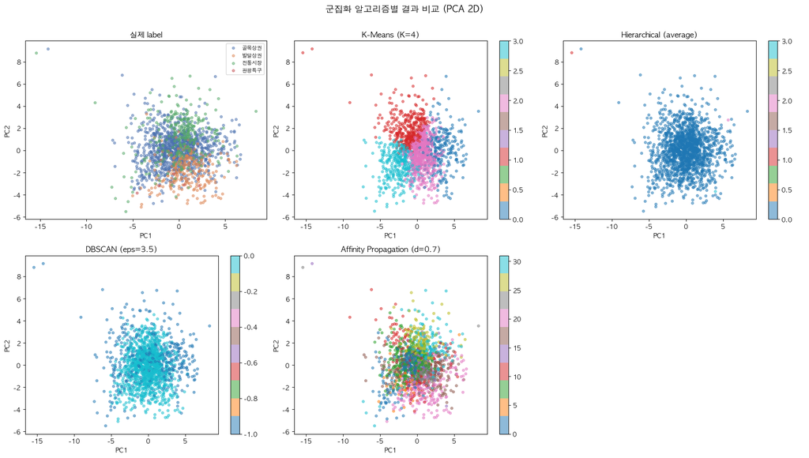

```python
fig, axes = plt.subplots(2, 3, figsize=(18, 10))
axes = axes.flatten()

plot_data = [
    ('실제 label', y_true_str, None),
    (f'K-Means (K={BEST_K})', km_labels, 'tab10'),
    (f'Hierarchical ({best_method})', hier_labels, 'tab10'),
    (f'DBSCAN (eps={BEST_EPS})', db_labels, 'tab10'),
    (f'Affinity Propagation (d={BEST_DAMPING})', ap_labels, 'tab10'),
]

for i, (title, labels, cmap) in enumerate(plot_data):
    if title == '실제 label':
        for label_name, color in label_colors.items():
            mask = y_true_str == label_name
            axes[i].scatter(X_pca2[mask, 0], X_pca2[mask, 1],
                            c=color, label=label_name, alpha=0.5, s=15)
        axes[i].legend(fontsize=8)
    else:
        sc = axes[i].scatter(X_pca2[:, 0], X_pca2[:, 1],
                             c=labels, cmap=cmap, alpha=0.5, s=15)
        plt.colorbar(sc, ax=axes[i])
    axes[i].set_title(title)
    axes[i].set_xlabel('PC1')
    axes[i].set_ylabel('PC2')

axes[-1].axis('off')

plt.suptitle('군집화 알고리즘별 결과 비교 (PCA 2D)', fontsize=14, y=1.01)
plt.tight_layout()
plt.savefig('plot_all_comparison.png', dpi=150, bbox_inches='tight')
plt.show()
```

### 4-5. K-Means 군집 특성 분석 (실제 label과 비교)

```
=== K-Means 군집별 실제 상권 구분 분포 ===
상권_구분_코드_명    골목상권  관광특구  발달상권  전통시장
kmeans_label
0              196     0    28    36
1              244     0     3   103
2              336     5   191   101
3              259     1    27    40
```

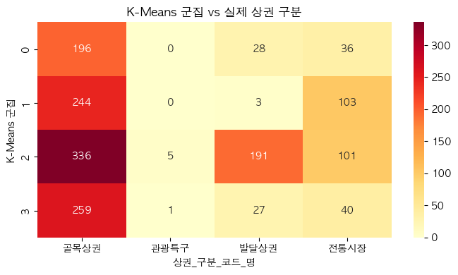

```python
# 군집별 실제 label 분포
print('=== K-Means 군집별 실제 상권 구분 분포 ===')
cross_tab = pd.crosstab(df_feat['kmeans_label'], df_feat['상권_구분_코드_명'])
print(cross_tab)

# 히트맵
plt.figure(figsize=(7, 4))
sns.heatmap(cross_tab, annot=True, fmt='d', cmap='YlOrRd')
plt.title('K-Means 군집 vs 실제 상권 구분')
plt.ylabel('K-Means 군집')
plt.tight_layout()
plt.savefig('plot_kmeans_heatmap.png', dpi=150, bbox_inches='tight')
plt.show()
```

```python
# 군집별 주요 feature 평균 (원래 스케일)
df_feat_orig = df.copy()
df_feat_orig['kmeans_label'] = km_labels
df_feat_orig = df_feat_orig[df_feat_orig['당월_매출_금액'] > 0].reset_index(drop=True)

key_cols = ['당월_매출_금액', '주중_매출_비율', '주말_매출_비율',
            '여성_매출_비율', '연령대_20_비율', '연령대_30_비율',
            '연령대_50_비율', '시간대_17~21_비율', '시간대_21~24_비율',
            '점포_수', '프랜차이즈_비율']

# df_feat에 있는 비율 컬럼 사용
cluster_profile = df_feat.groupby('kmeans_label')[FEATURE_COLS].mean().round(3)
print('\n=== K-Means 군집별 feature 평균 (표준화 전) ===')
print(cluster_profile.T.to_string())
```

```
=== K-Means 군집별 feature 평균 (표준화 전) ===
kmeans_label       0       1       2       3
당월_매출_금액      20.988  20.729  23.059  21.474
주중_매출_비율       0.890   0.684   0.772   0.709
주말_매출_비율       0.110   0.316   0.228   0.291
월요일_매출_비율      0.186   0.126   0.154   0.126
화요일_매출_비율      0.192   0.144   0.165   0.146
수요일_매출_비율      0.160   0.133   0.138   0.139
목요일_매출_비율      0.179   0.134   0.145   0.140
금요일_매출_비율      0.172   0.147   0.170   0.158
토요일_매출_비율      0.078   0.183   0.145   0.171
일요일_매출_비율      0.032   0.133   0.083   0.120
시간대_00~06_비율   0.009   0.018   0.026   0.071
시간대_06~11_비율   0.126   0.075   0.116   0.056
시간대_11~14_비율   0.338   0.253   0.254   0.177
시간대_14~17_비율   0.259   0.237   0.242   0.153
시간대_17~21_비율   0.225   0.341   0.283   0.355
시간대_21~24_비율   0.043   0.077   0.080   0.187
여성_매출_비율       0.393   0.422   0.442   0.389
연령대_10_비율      0.002   0.002   0.004   0.011
연령대_20_비율      0.046   0.058   0.075   0.180
연령대_30_비율      0.135   0.132   0.155   0.221
연령대_40_비율      0.214   0.185   0.224   0.180
연령대_50_비율      0.194   0.250   0.221   0.181
연령대_60_이상_비율   0.233   0.290   0.235   0.137
점포_수           4.619   4.334   5.731   4.899
프랜차이즈_비율       0.072   0.067   0.095   0.106
개업_비율          0.017   0.022   0.023   0.028
폐업_비율          0.024   0.028   0.028   0.031
총_직장_인구_수      6.269   5.112   7.239   5.881
직장_여성_비율       0.397   0.373   0.409   0.401
직장_2030_비율     0.398   0.289   0.378   0.367
```

```
=== 군집 구분 기여도 상위 10개 변수 (군집 간 분산 / 군집 내 분산) ===
주말_매출_비율        1.5372
주중_매출_비율        1.5372
시간대_21~24_비율    0.8762
토요일_매출_비율       0.7858
일요일_매출_비율       0.7715
연령대_20_비율       0.6346
시간대_00~06_비율    0.5342
점포_수            0.3878
시간대_11~14_비율    0.3247
당월_매출_금액        0.3168
dtype: float64
```

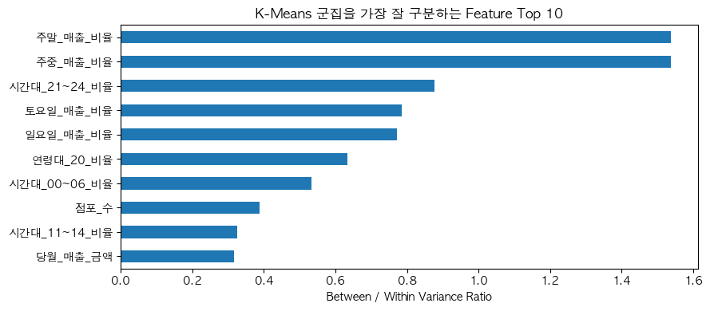

```python
# 군집 구분에 가장 기여한 변수 (군집 간 분산 / 전체 분산)
f_scores = {}
for col in FEATURE_COLS:
    group_means = df_feat.groupby('kmeans_label')[col].mean()
    overall_mean = df_feat[col].mean()
    between_var = ((group_means - overall_mean)**2).mean()
    within_var = df_feat.groupby('kmeans_label')[col].var().mean()
    f_scores[col] = between_var / (within_var + 1e-9)

f_df = pd.Series(f_scores).sort_values(ascending=False)
print('=== 군집 구분 기여도 상위 10개 변수 (군집 간 분산 / 군집 내 분산) ===')
print(f_df.head(10).round(4))

plt.figure(figsize=(9, 4))
f_df.head(10).plot(kind='barh')
plt.xlabel('Between / Within Variance Ratio')
plt.title('K-Means 군집을 가장 잘 구분하는 Feature Top 10')
plt.gca().invert_yaxis()
plt.tight_layout()
plt.savefig('plot_feature_importance.png', dpi=150, bbox_inches='tight')
plt.show()
```

## 결과 요약 및 해석

| 알고리즘 | 주요 하이퍼파라미터 | 군집 수 | Silhouette |
| --- | --- | --- | --- |
| K-Means | K=4 | 4 | 0.0781 |
| Hierarchical | linkage=average | 4 | 0.7134 ※ |
| DBSCAN | eps=3.5, min_samples=4 | 1 | - |
| Affinity Propagation | damping=0.7, preference=-200 | 32 | 0.0272 |

※ Average/Complete linkage의 높은 Silhouette은 1,500개 이상이 단일 군집으로 쏠리는 극단적 불균형에서 발생한 Metric Inflation이며 실질적 군집 능력이 없음. Ward linkage(0.0575)가 시각적으로도 더 유의미한 분리를 보임.